# Introduction

Traditionally, human activity recognition research (HAR) has focused on discriminating between different activities. The current analysis is based on a dataset which has been constructed with the purpose to investigate “how (well)” a weight lifting exercise was performed by the wearer.

As explained in the documentation to the dataset, 6 young health participants were asked to perform one set of 10 repetitions of the Unilateral Dumbbell Biceps Curl in five different fashions: Class A corresponds to the specified execution of the exercise, while the other 4 classes correspond to common mistakes.

# Initial data analysis

Both the training and the test data have been obtained directly from the course website.

The variable *classe* is included in the training data set but not in the test data set, while variable *problem_id* is included in the test data set but not in the training data set. Thus, the test data cannot be used to verify the out of sample error, and we will need to create a separate validation data set - see further).

As shown below, the training datatset is distributed more or less proportionally over the five Classes - there are thus no issues of class unbalance.

```
##    A    B    C    D    E
## 5580 3797 3422 3216 3607
```

However, it turns out that there are 60 variables with near zero variance in the training data set. These variables are eliminated from both the training and the test dataset.

Several variables (“X”, “user_name”, “raw_timestamp_part_1” , “raw_timestamp_part_2”, “cvtd_timestamp”, “num_window”) identify the observation, but do not describe the physical activity linked to the actual weight lifting exercise. These have also been eliminated from both data sets.

As noted above, the existing test data set does not contain the actual “class” value. Therefore, in order to obtain an estimate of the out of sample error, we further divide the “train” data set in a “train” and in a “validation” data set:

```r
inTrain <- createDataPartition(y = train$classe, p =0.8, list = FALSE)

train <- train[inTrain, ]
valid <- train[-inTrain, ]
```

# Estimates

As the dependent variable is categorical, the use of linear regression is not appropriate for this model. Moreover, as the number of categories exceeds two, the use of a binary logit model can also be excluded.

We have considered using linear discriminant analysis. While an accuracy of 0.701 is not a bad result, this performance is much lower than that of the alternatives that are described below, and it will not be discussed further.

## Boosting with trees

We have first considered fitting a “boosting with trees” model.

```
## A gradient boosted model with multinomial loss function.
## 150 iterations were performed.
## There were 52 predictors of which 41 had non-zero influence.
```

```
## Stochastic Gradient Boosting
##
## 15699 samples
##    52 predictor
##     5 classes: 'A', 'B', 'C', 'D', 'E'
##
## Pre-processing: centered, scaled
## Resampling: Bootstrapped (25 reps)
##
## Summary of sample sizes: 15699, 15699, 15699, 15699, 15699, 15699, ...
##
## Resampling results across tuning parameters:
##
##   interaction.depth  n.trees  Accuracy  Kappa  Accuracy SD  Kappa SD
##   1                   50      0.747     0.680  0.00626      0.00787
##   1                  100      0.817     0.768  0.00463      0.00589
##   1                  150      0.849     0.809  0.00522      0.00661
##   2                   50      0.853     0.814  0.00564      0.00716
##   2                  100      0.904     0.879  0.00473      0.00598
##   2                  150      0.928     0.909  0.00369      0.00467
##   3                   50      0.894     0.866  0.00496      0.00631
##   3                  100      0.939     0.923  0.00395      0.00498
##   3                  150      0.958     0.946  0.00293      0.00369
##
## Tuning parameter 'shrinkage' was held constant at a value of 0.1
## Accuracy was used to select the optimal model using  the largest value.
## The final values used for the model were n.trees = 150,
##  interaction.depth = 3 and shrinkage = 0.1.
```

Initially, the model has been bootstrapped for the purpose of cross validation with resamples. This leads to an in-sample accuracy of 0.958 for the preferred model. We also see that increasing the number of iterations and the maximum tree depth have a positive influence on the accuracy of the estimates:

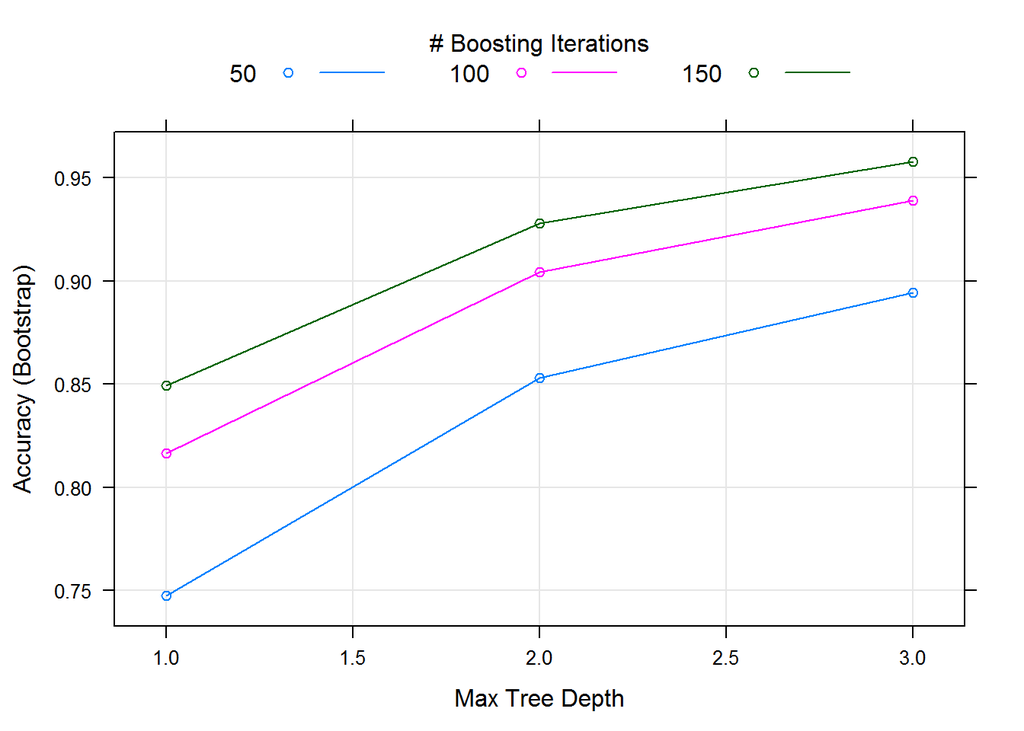

We have repeated the same estimation method, but we used K-foll cross-validation, with K = 10.

This leads to an in-sample accuracy of 0.962 for the preferred model.

```
## A gradient boosted model with multinomial loss function.
## 150 iterations were performed.
## There were 52 predictors of which 41 had non-zero influence.
```

```
## Stochastic Gradient Boosting
##
## 15699 samples
##    52 predictor
##     5 classes: 'A', 'B', 'C', 'D', 'E'
##
## Pre-processing: centered, scaled
## Resampling: Cross-Validated (10 fold, repeated 10 times)
##
## Summary of sample sizes: 14130, 14129, 14127, 14129, 14129, 14129, ...
##
## Resampling results across tuning parameters:
##
##   interaction.depth  n.trees  Accuracy  Kappa  Accuracy SD  Kappa SD
##   1                   50      0.750     0.683  0.01134      0.01438
##   1                  100      0.821     0.773  0.00978      0.01235
##   1                  150      0.854     0.815  0.00934      0.01180
##   2                   50      0.857     0.819  0.00922      0.01168
##   2                  100      0.907     0.883  0.00771      0.00976
##   2                  150      0.932     0.914  0.00583      0.00737
##   3                   50      0.897     0.870  0.00736      0.00932
##   3                  100      0.942     0.927  0.00591      0.00748
##   3                  150      0.962     0.952  0.00479      0.00606
##
## Tuning parameter 'shrinkage' was held constant at a value of 0.1
## Accuracy was used to select the optimal model using  the largest value.
## The final values used for the model were n.trees = 150,
##  interaction.depth = 3 and shrinkage = 0.1.
```

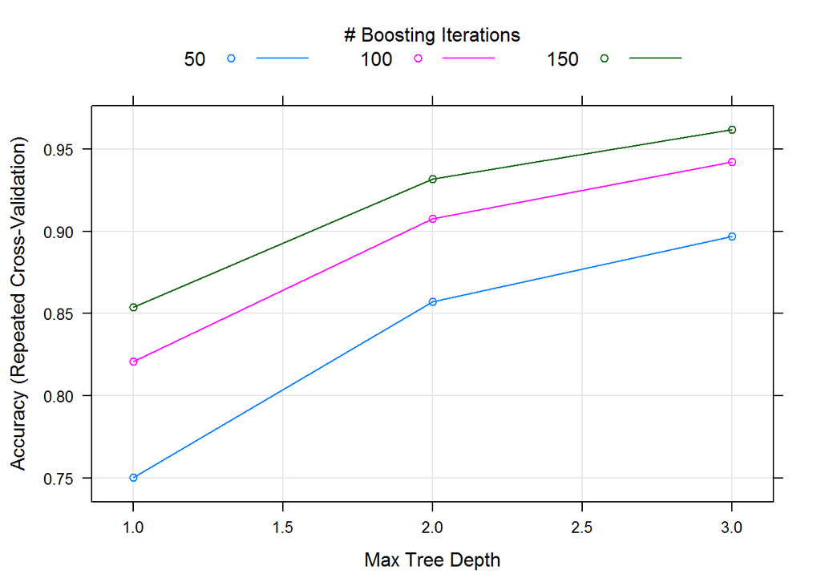

The out-of-sample accuracy (in the validation set) for the bootstrapped model (0.9752) is sligtly higher than for the K-fold cross-validated model (0.9749). This is substantially better than the linear discriminant model, but we shall show below it is possible to even further improve on this.

## Random forest models

We have then fitted a random forest with the default parameters from the “caret” package:

The model has been bootstrapped for the purpose of cross validation with 25 resamples and the accuracy as performance metric. In the preferred model, 2 features are selected randomly at each split. This leads to an in-sample accuracy of 0.99.

```
## Random Forest
##
## 15699 samples
##    52 predictor
##     5 classes: 'A', 'B', 'C', 'D', 'E'
##
## Pre-processing: centered, scaled
## Resampling: Bootstrapped (25 reps)
##
## Summary of sample sizes: 15699, 15699, 15699, 15699, 15699, 15699, ...
##
## Resampling results across tuning parameters:
##
##   mtry  Accuracy  Kappa  Accuracy SD  Kappa SD
##    2    0.990     0.988  0.00174      0.00220
##   27    0.990     0.987  0.00191      0.00242
##   52    0.981     0.976  0.00495      0.00627
##
## Accuracy was used to select the optimal model using  the largest value.
## The final value used for the model was mtry = 2.
```

The final model results in a collection of 500 trees. The 5 most important features are:

```
##         roll_belt          yaw_belt magnet_dumbbell_z        pitch_belt
##          573.8750          496.2699          429.4276          403.2312
## magnet_dumbbell_y     pitch_forearm
##          402.0731          391.2683
```

We have also fitted a second random forest, but instead of bootstrap resampling, we used K-fold cross-validation, with K = 10. In the preferred model, 2 features are selected randomly at each split. This leads to an in-sample accuracy of 0.994.

```
## Random Forest
##
## 15699 samples
##    52 predictor
##     5 classes: 'A', 'B', 'C', 'D', 'E'
##
## Pre-processing: centered, scaled
## Resampling: Cross-Validated (10 fold, repeated 10 times)
##
## Summary of sample sizes: 14130, 14131, 14129, 14129, 14128, 14128, ...
##
## Resampling results across tuning parameters:
##
##   mtry  Accuracy  Kappa  Accuracy SD  Kappa SD
##    2    0.994     0.992  0.00191      0.00242
##   27    0.994     0.992  0.00219      0.00277
##   52    0.988     0.985  0.00340      0.00430
##
## Accuracy was used to select the optimal model using  the largest value.
## The final value used for the model was mtry = 2.
```

The 5 most important features are:

```
##         roll_belt          yaw_belt magnet_dumbbell_z     pitch_forearm
##          585.4992          491.1548          424.9004          417.8706
## magnet_dumbbell_y        pitch_belt
##          391.1795          389.8944
```

Both “random forest” models result in identical predictions in the validation data set. Therefore, stacking these models will not improve performance.

```r
predRF <- predict(modFitRF,valid)
predRFk <- predict(modFitRFkfold,valid)
all.equal(predRF,predRFk)
```

```
## [1] TRUE
```

Moreover, the “random forest” model perfectly predicts all values in the validation set:

```r
all.equal(valid$classe, predRF)
```

```
## [1] TRUE
```

# Conclusion

We have tested several predictive models to investigate “how (well)” a weight lifting exercise was performed by the wearer.

Tree based models clearly outperform linear discriminant analysis. “Random forest” model perform best, both inside and outside the sample (with a 100% accuracy for the current validation data set). Taking into account its shorter running time, we prefer a bootstrapped model to the k-fold cross-validated model.

It should however be noted that the “boosted trees” model also perform extremely well, both inside and outside the sample.

# Reference

Velloso, E.; Bulling, A.; Gellersen, H.; Ugulino, W.; Fuks, H. Qualitative Activity Recognition of Weight Lifting Exercises. Proceedings of 4th International Conference in Cooperation with SIGCHI (Augmented Human ’13) . Stuttgart, Germany: ACM SIGCHI, 2013.